# Proyecto Final

Michelle Audirac

18 Diciembre, 2017

EDA (R) Limpieza (R) Imputación (R o Python) Transformación (Python) Ingeniería de características (Python) Selección (Python) Filtrado (Python) Predicción con pipelines (multiples algoritmos) (Python) Medición entrega de reporte reproducible con instrucciones para ejecución

For this competition, you are tasked with categorizing shopping trip types based on the items that customers purchased. To give a few hypothetical examples of trip types: a customer may make a small daily dinner trip, a weekly large grocery trip, a trip to buy gifts for an upcoming holiday, or a seasonal trip to buy clothes.

Walmart has categorized the trips contained in this data into 38 distinct types using a proprietary method applied to an extended set of data. You are challenged to recreate this categorization/clustering with a more limited set of features. This could provide new and more robust ways to categorize trips.

The training set (train.csv) contains a large number of customer visits with the TripType included. You must predict the TripType for each customer visit in the test set (test.csv). Each visit may only have one TripType. You will not be provided with more information than what is given in the data (e.g. what the TripTypes represent or more product information).

The test set file is encrypted. You must complete this brief survey to receive the password.

Data fields

TripType - a categorical id representing the type of shopping trip the customer made. This is the ground truth that you are predicting. TripType_999 is an “other” category. VisitNumber - an id corresponding to a single trip by a single customer Weekday - the weekday of the trip Upc - the UPC number of the product purchased ScanCount - the number of the given item that was purchased. A negative value indicates a product return. DepartmentDescription - a high-level description of the item’s department FinelineNumber - a more refined category for each of the products, created by Walmart

## Carga y preparación

En esta sección cargamos y preparamos los datasets `train`y `test`.

**train**

- Cargamos los datos `train`

```r
train <- read.csv('../data/train.csv')
```

- Validamos la clase del objeto `train`

```r
class(train)
```

```
## [1] "data.frame"
```

- Observamos la estructura de `train`

```r
str(train)
```

```
## 'data.frame':    647054 obs. of  7 variables:
##  $ TripType             : int  999 30 30 26 26 26 26 26 26 26 ...
##  $ VisitNumber          : int  5 7 7 8 8 8 8 8 8 8 ...
##  $ Weekday              : Factor w/ 7 levels "Friday","Monday",..: 1 1 1 1 1 1 1 1 1 1 ...
##  $ Upc                  : num  6.81e+10 6.05e+10 7.41e+09 2.24e+09 2.01e+09 ...
##  $ ScanCount            : int  -1 1 1 2 2 2 1 1 1 -1 ...
##  $ DepartmentDescription: Factor w/ 69 levels "1-HR PHOTO","ACCESSORIES",..: 21 64 52 51 51 51 51 51 51 51 ...
##  $ FinelineNumber       : int  1000 8931 4504 3565 1017 1017 1017 2802 4501 3565 ...
```

- Modificamos la clase de algunas columnas de `train`

```r
train$TripType <- as.factor(train$TripType)
train$VisitNumber <- as.factor(train$VisitNumber)
train$Upc <- as.factor(train$Upc)
train$FinelineNumber <- as.factor(train$FinelineNumber)
```

**test**

- Cargamos los datos `test`

```r
test <- read.csv('../data/test.csv')
```

- Validamos la clase del objeto `test`

```r
class(test)
```

```
## [1] "data.frame"
```

- Observamos la estructura de `test`

```r
str(test)
```

```
## 'data.frame':    653646 obs. of  6 variables:
##  $ VisitNumber          : int  1 1 1 1 2 2 2 2 3 3 ...
##  $ Weekday              : Factor w/ 7 levels "Friday","Monday",..: 1 1 1 1 1 1 1 1 1 1 ...
##  $ Upc                  : num  7.25e+10 1.71e+09 8.95e+10 8.85e+10 2.84e+09 ...
##  $ ScanCount            : int  1 1 1 1 1 1 1 1 1 -1 ...
##  $ DepartmentDescription: Factor w/ 68 levels "1-HR PHOTO","ACCESSORIES",..: 63 17 17 25 18 4 32 32 51 51 ...
##  $ FinelineNumber       : int  3002 1526 1431 3555 4408 5019 8023 8023 4504 4504 ...
```

- Modificamos la clase de algunas columnas de `test`

```r
test$VisitNumber <- as.factor(test$VisitNumber)
test$Upc <- as.factor(test$Upc)
test$FinelineNumber <- as.factor(test$FinelineNumber)
```

## EDA y limpieza

### Exploración univariada

En esta sección hacemos una exploración univarida de las columnas en `test`. También se exploran las columnas en `train` para valorar qué tipo de imputaciones debemos realizar más adelante.

#### Campos vacíos

**train**

- Cuántos NAs hay por columna en el dataset `train`?

```r
apply(train, 2, function(x) sum(is.na(x)))
```

```
##              TripType           VisitNumber               Weekday
##                     0                     0                     0
##                   Upc             ScanCount DepartmentDescription
##                  4129                     0                     0
##        FinelineNumber
##                  4129
```

- Cuántos NULLs hay por columna en el dataset `train`?

```r
apply(train, 2, function(x) sum(is.null(x)))
```

```
##              TripType           VisitNumber               Weekday
##                     0                     0                     0
##                   Upc             ScanCount DepartmentDescription
##                     0                     0                     0
##        FinelineNumber
##                     0
```

**test**

- Cuántos NAs hay por columna en el dataset `test`?

```r
apply(test, 2, function(x) sum(is.na(x)))
```

```
##           VisitNumber               Weekday                   Upc
##                     0                     0                  3986
##             ScanCount DepartmentDescription        FinelineNumber
##                     0                     0                  3986
```

- Cuántos NULLs hay por columna en el dataset `test`?

```r
apply(test, 2, function(x) sum(is.null(x)))
```

```
##           VisitNumber               Weekday                   Upc
##                     0                     0                     0
##             ScanCount DepartmentDescription        FinelineNumber
##                     0                     0                     0
```

#### TripType

`TripType` es una variable categórica

**train**

- Cuántas categorías tiene `TripType` en el dataset `train`?

```r
print(paste('numero de categorias:', length(levels(train$TripType))))
```

```
## [1] "numero de categorias: 38"
```

- Qué categorías y cuántas observaciones por categoría tiene `TripType` en el dataset `train`?

```r
print(summary(train$TripType))
```

```
##      3      4      5      6      7      8      9     12     14     15
##   6827    901  13836   3405  23199  22844  16820   2108     35   7147
##     18     19     20     21     22     23     24     25     26     27
##   2977   1188   3116   4032   3592    325  18015  27609   2507   4613
##     28     29     30     31     32     33     34     35     36     37
##   2664   2105   4861   1765  13843   9918   4751  12501  21990  38954
##     38     39     40     41     42     43     44    999
##  29565  95504 174164   5508  19468   6383  20424  17590
```

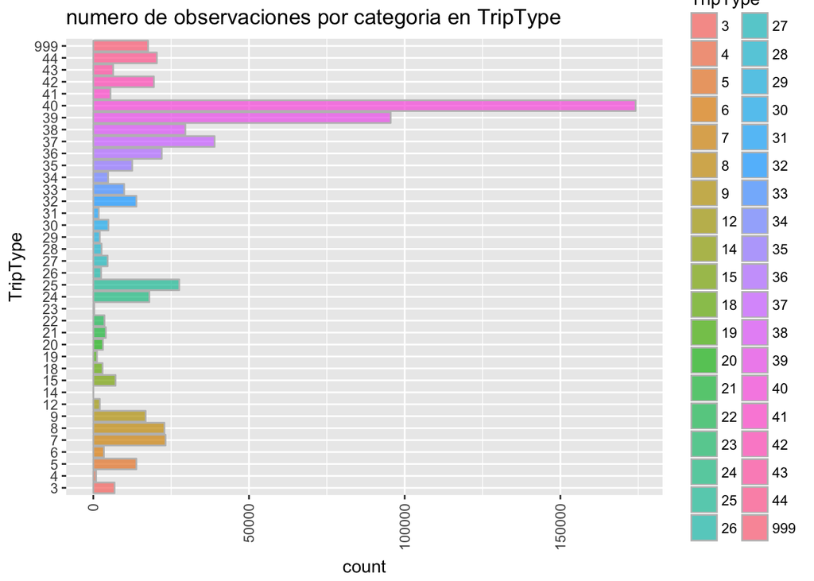

```r
ggplot(train, aes(TripType, fill = TripType)) +
  geom_bar(colour = 'grey', alpha = 0.7) +
  theme(axis.text.x = element_text(angle = 90, vjust = 0.5, hjust=1)) +
  labs(title = "numero de observaciones por categoria en TripType", x = "TripType", y = "count") +
  coord_flip()
```

- Cuál es el resumen y el histograma del número de observaciones por categoría en `TripType` en el dataset `train`?

```r
summary(as.data.frame(table(train$TripType))$Freq)
```

```
##    Min. 1st Qu.  Median    Mean 3rd Qu.    Max.
##      35    3012    6605   17030   19100  174200
```

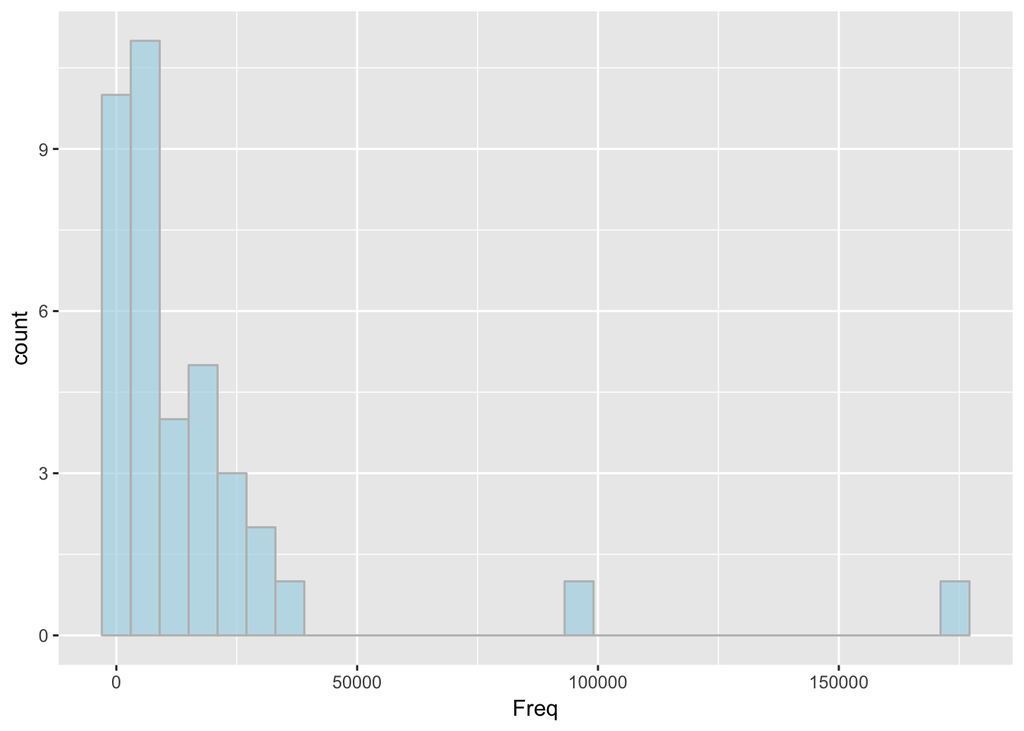

```r
ggplot(as.data.frame(table(train$TripType)), aes(x = Freq)) +
  geom_histogram(colour = 'grey', fill = 'lightblue', alpha = 0.7)
```

#### VisitNumber

`VisitNumber` es una variable categórica

**train**

- Cuántas categorías tiene `VisitNumber`en el dataset `train`?

```r
print(paste('numero de categorias:', length(levels(train$VisitNumber))))
```

```
## [1] "numero de categorias: 95674"
```

- Cuál es el resumen y el boxplot del número de observaciones por categoría en `VisitNumber` en el dataset `train`?

```r
summary(as.data.frame(table(train$VisitNumber))$Freq)
```

```
##    Min. 1st Qu.  Median    Mean 3rd Qu.    Max.
##   1.000   2.000   4.000   6.763   8.000 209.000
```

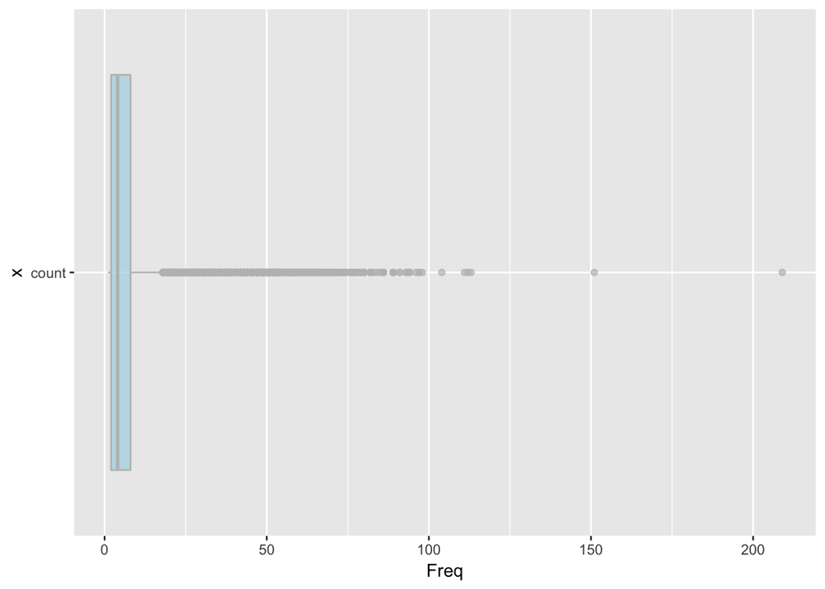

```r
ggplot(as.data.frame(table(train$VisitNumber)), aes(x = 'count', y = Freq)) +
  geom_boxplot(colour = 'grey', fill = 'lightblue', alpha = 0.7) +
  coord_flip()
```

**test**

- Cuántas categorías tiene `VisitNumber` en el dataset `test`?

```r
print(paste('numero de categorias:', length(levels(test$VisitNumber))))
```

```
## [1] "numero de categorias: 95674"
```

- Cuál es el resumen y el boxplot del número de observaciones por categoría en `VisitNumber` en el dataset `test`?

```r
summary(as.data.frame(table(test$VisitNumber))$Freq)
```

```
##    Min. 1st Qu.  Median    Mean 3rd Qu.    Max.
##   1.000   2.000   4.000   6.832   8.000 154.000
```

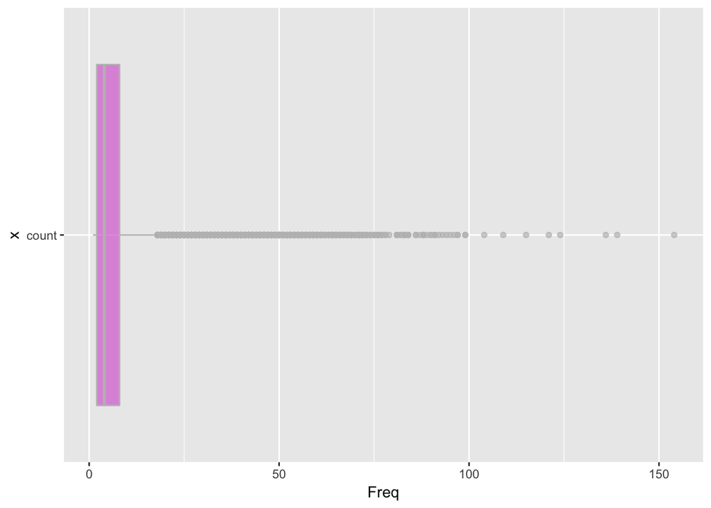

```r
ggplot(as.data.frame(table(test$VisitNumber)), aes(x = 'count', y = Freq)) +
  geom_boxplot(colour = 'grey', fill = 'orchid', alpha = 0.7) +
  coord_flip()
```

#### Weekday

`Weekday` es una variable categórica

**train**

- Qué categorías y cuántas observaciones por categoría tiene `Weekday` en el dataset `train`?

```r
print(summary(train$Weekday))
```

```
##    Friday    Monday  Saturday    Sunday  Thursday   Tuesday Wednesday
##     96247     83130    122096    133975     67962     72529     71115
```

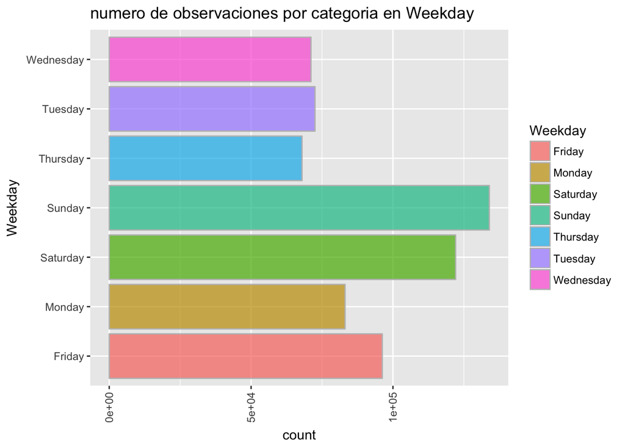

```r
ggplot(train, aes(Weekday, fill = Weekday)) +
  geom_bar(colour = 'grey', alpha = 0.7) +
  theme(axis.text.x = element_text(angle = 90, vjust = 0.5, hjust=1)) +
  labs(title = "numero de observaciones por categoria en Weekday", x = "Weekday", y = "count") +
  coord_flip()
```

**test**

- Qué categorías y cuántas observaciones por categoría tiene `Weekday` en el dataset `test`?

```r
print(summary(test$Weekday))
```

```
##    Friday    Monday  Saturday    Sunday  Thursday   Tuesday Wednesday
##     94764     85174    123974    133233     70278     73742     72481
```

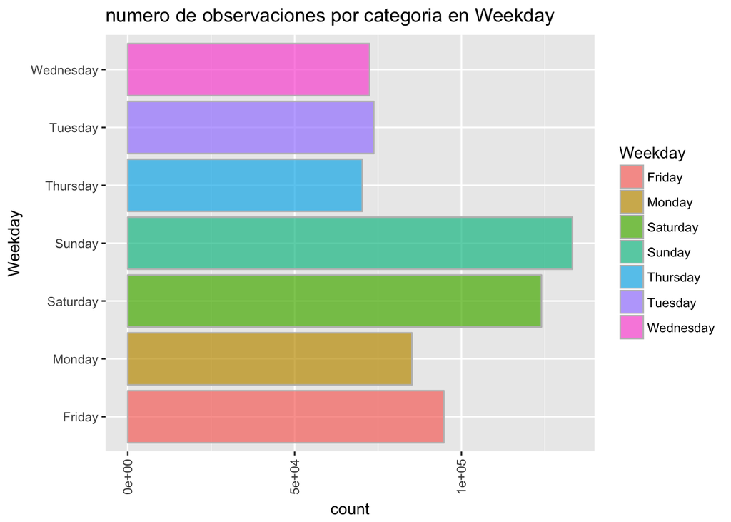

```r
ggplot(test, aes(Weekday, fill = Weekday)) +
  geom_bar(colour = 'grey', alpha = 0.7) +
  theme(axis.text.x = element_text(angle = 90, vjust = 0.5, hjust=1)) +
  labs(title = "numero de observaciones por categoria en Weekday", x = "Weekday", y = "count") +
  coord_flip()
```

#### Upc

`Upc` es una variable categórica

**train**

- Cuántas categorías tiene `Upc` en el dataset `train`?

```r
print(paste('numero de categorias:', length(levels(train$Upc))))
```

```
## [1] "numero de categorias: 97714"
```

- Cuál es el resumen y el boxplot del número de observaciones por categoría en `Upc` en el dataset `train`?

```r
n_Upc <- as.data.frame(table(train$Upc))
summary(n_Upc$Freq)
```

```
##    Min. 1st Qu.  Median    Mean 3rd Qu.    Max.
##    1.00    1.00    2.00    6.58    5.00 7657.00
```

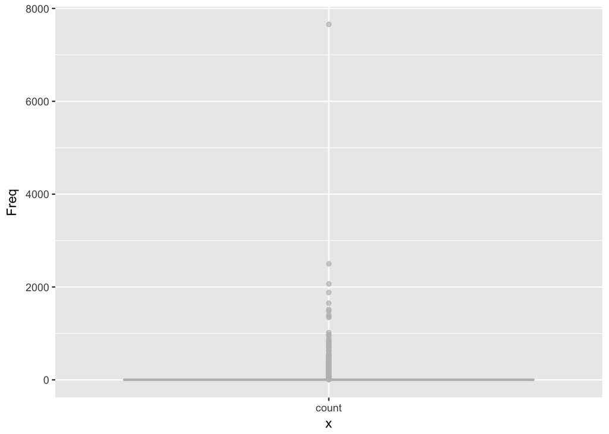

```r
ggplot(n_Upc, aes(x = 'count', y = Freq)) +
  geom_boxplot(colour = 'grey', fill = 'lightblue', alpha = 0.7)
```

- Cuál es el histograma del número de observaciones por categoría en `Upc` en el dataset `train`?

Eliminamos aquellas categorías en `Upc` que tienen más de 200 observaciones.

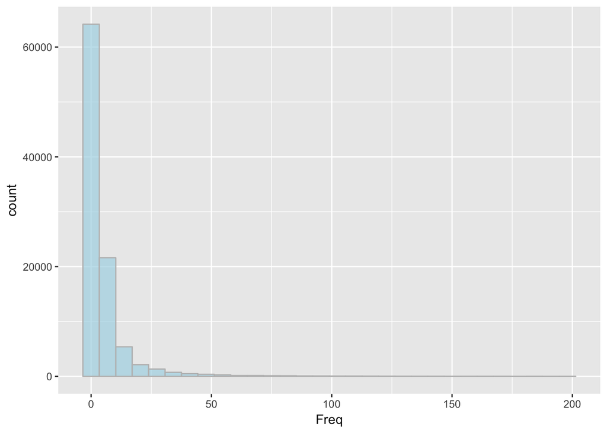

```r
ggplot(n_Upc[n_Upc$Freq < 200, ], aes(x = Freq)) +
  geom_histogram(colour = 'grey', fill = 'lightblue', alpha = 0.7)
```

**test**

- Cuántas categorías tiene `Upc` en el dataset `test`?

```r
print(paste('numero de categorias:', length(levels(test$Upc))))
```

```
## [1] "numero de categorias: 98147"
```

- Cuál es el resumen y el boxplot del número de observaciones por categoría en `Upc` en el dataset `test`?

```r
n_Upc <- as.data.frame(table(test$Upc))
summary(n_Upc$Freq)
```

```
##     Min.  1st Qu.   Median     Mean  3rd Qu.     Max.
##    1.000    1.000    2.000    6.619    5.000 7558.000
```

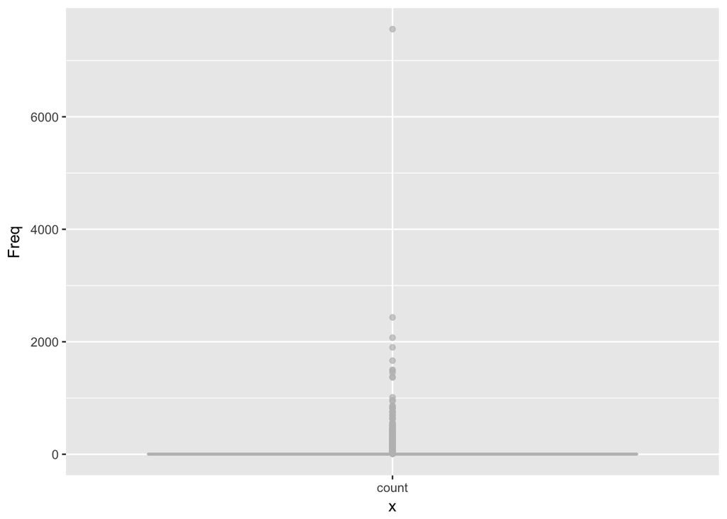

```r
ggplot(n_Upc, aes(x = 'count', y = Freq)) +
  geom_boxplot(colour = 'grey', fill = 'orchid', alpha = 0.7)
```

Cuál es el histograma del número de observaciones por categoría en `Upc` en el dataset `test`?

Eliminamos aquellas categorías en `Upc` que tienen más de 200 observaciones

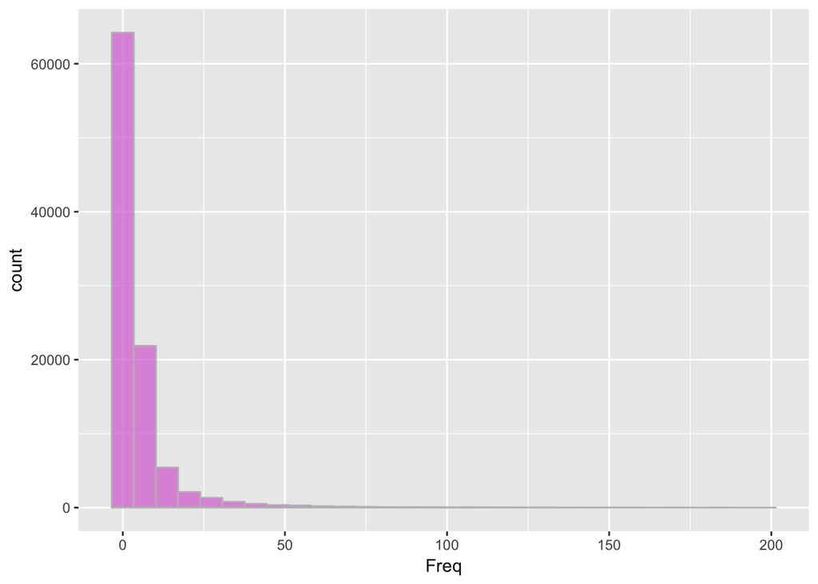

```r
ggplot(n_Upc[n_Upc$Freq < 200, ], aes(x = Freq)) +
  geom_histogram(colour = 'grey', fill = 'orchid', alpha = 0.7)
```

#### FinelineNumber

`FinelineNumber` es una variable categórica

**train**

- Cuántas categorías tiene `FinelineNumber` en el dataset `train`?

```r
print(paste('numero de categorias:', length(levels(train$FinelineNumber))))
```

```
## [1] "numero de categorias: 5195"
```

- Cuál es el resumen y el boxplot del número de observaciones por categoría en `FinelineNumber` en el dataset `train`?

```r
n_FinelineNumber <- as.data.frame(table(train$FinelineNumber))
summary(n_FinelineNumber$Freq)
```

```
##    Min. 1st Qu.  Median    Mean 3rd Qu.    Max.
##     1.0    10.0    35.0   123.8   115.0  8244.0
```

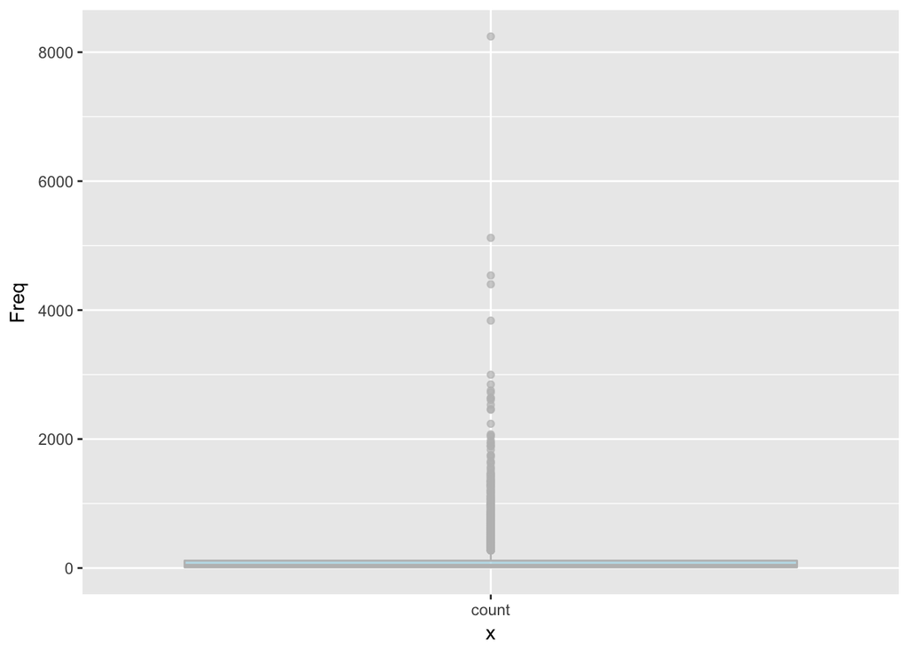

```r
ggplot(n_FinelineNumber, aes(x = 'count', y = Freq)) +
  geom_boxplot(colour = 'grey', fill = 'lightblue', alpha = 0.7)
```

Cuál es el histograma del número de observaciones por categoría en `FinelineNumber` en el dataset `train`?

Eliminamos aquellas categorías en `FinelineNumber` que tienen más de 500 observaciones

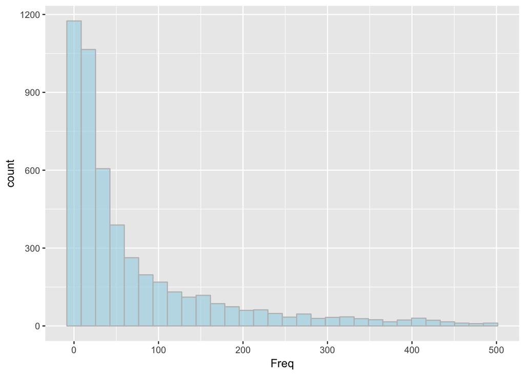

```r
ggplot(n_FinelineNumber[n_FinelineNumber$Freq < 500, ], aes(x = Freq)) +
  geom_histogram(colour = 'grey', fill = 'lightblue', alpha = 0.7)
```

**test**

- Cuántas categorías tiene `FinelineNumber` en el dataset `test`?

```r
print(paste('numero de categorias:', length(levels(test$FinelineNumber))))
```

```
## [1] "numero de categorias: 5203"
```

- Cuál es el resumen y el boxplot del número de observaciones por categoría en `FinelineNumber` en el dataset `test`?

```r
n_FinelineNumber <- as.data.frame(table(test$FinelineNumber))
summary(n_FinelineNumber$Freq)
```

```
##    Min. 1st Qu.  Median    Mean 3rd Qu.    Max.
##     1.0    10.0    34.0   124.9   114.0  8185.0
```

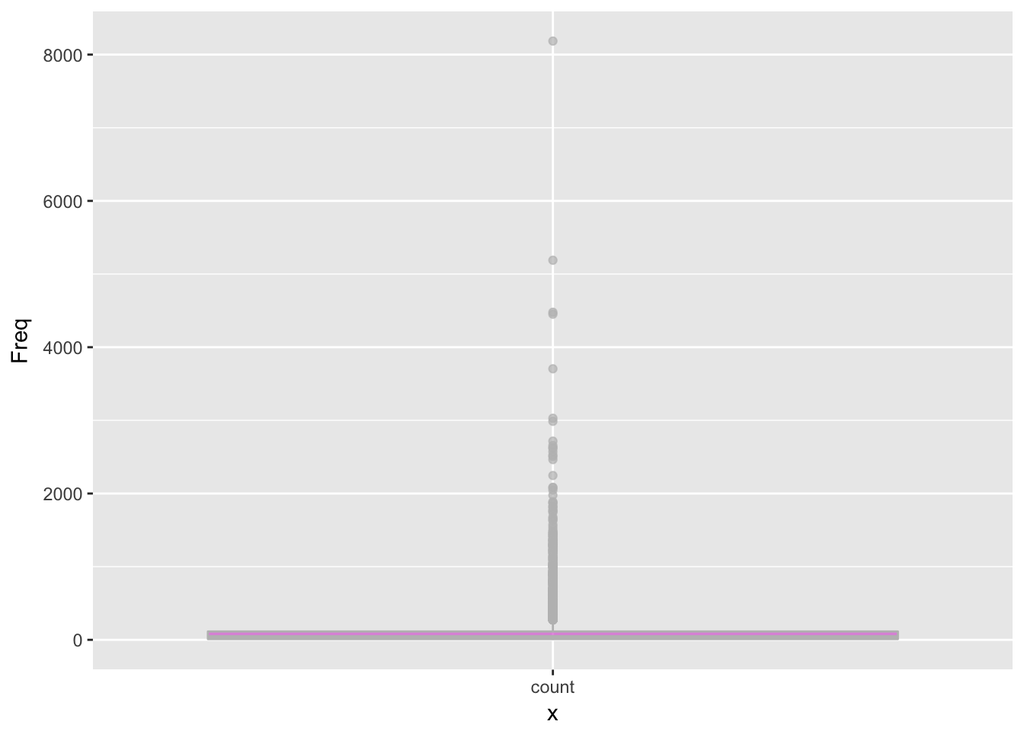

```r
ggplot(n_FinelineNumber, aes(x = 'count', y = Freq)) +
  geom_boxplot(colour = 'grey', fill = 'orchid', alpha = 0.7)
```

Cuál es el histograma del número de observaciones por categoría en `FinelineNumber` en el dataset `test`?

Eliminamos aquellas categorías en `FinelineNumber` que tienen más de 500 observaciones

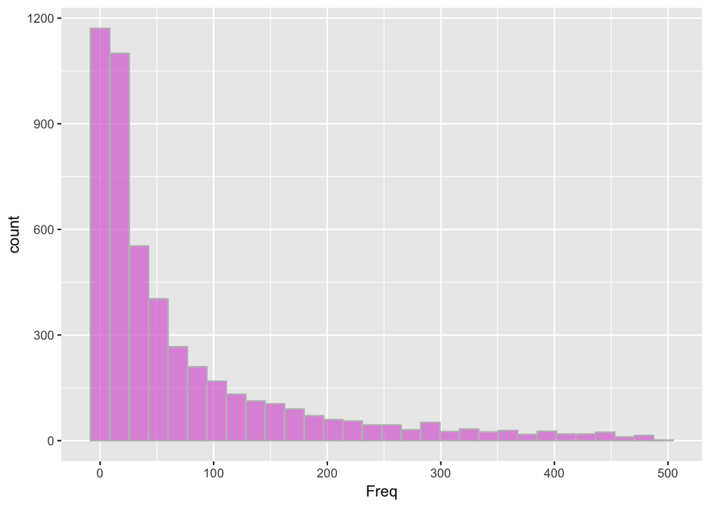

```r
ggplot(n_FinelineNumber[n_FinelineNumber$Freq < 500, ], aes(x = Freq)) +
  geom_histogram(colour = 'grey', fill = 'orchid', alpha = 0.7)
```

#### DepartmentDescription

`DepartmentDescription` es una variable categórica

**train**

- Cuántas categorías tiene `DepartmentDescription` en el dataset `train`?

```r
print(paste('numero de categorias:', length(levels(train$DepartmentDescription))))
```

```
## [1] "numero de categorias: 69"
```

- Qué categorías y cuántas observaciones por categoría tiene `DepartmentDescription` en el dataset `train`?

```r
print(summary(train$DepartmentDescription))
```

```
##                  1-HR PHOTO                 ACCESSORIES
##                         394                        1318
##                  AUTOMOTIVE                      BAKERY
##                        5414                        7168
##             BATH AND SHOWER                      BEAUTY
##                        4582                       14865
##                     BEDDING         BOOKS AND MAGAZINES
##                        2307                         992
##                   BOYS WEAR            BRAS & SHAPEWEAR
##                        3892                        2036
##        CAMERAS AND SUPPLIES     CANDY, TOBACCO, COOKIES
##                         221                        9808
##                 CELEBRATION                  COMM BREAD
##                        8698                       15244
##              CONCEPT STORES               COOK AND DINE
##                          35                        7600
##                       DAIRY                 DSD GROCERY
##                       43820                       68332
##                 ELECTRONICS          FABRICS AND CRAFTS
##                        3190                        5051
##          FINANCIAL SERVICES                FROZEN FOODS
##                       10723                       21101
##                   FURNITURE  GIRLS WEAR, 4-6X  AND 7-14
##                         477                        4516
##           GROCERY DRY GOODS                    HARDWARE
##                       70402                        4913
##      HEALTH AND BEAUTY AIDS                  HOME DECOR
##                           2                        4167
##             HOME MANAGEMENT     HORTICULTURE AND ACCESS
##                        6349                        2893
##    HOUSEHOLD CHEMICALS/SUPP       HOUSEHOLD PAPER GOODS
##                       24880                       16274
##         IMPULSE MERCHANDISE              INFANT APPAREL
##                       28712                        6051
## INFANT CONSUMABLE HARDLINES      JEWELRY AND SUNGLASSES
##                       10646                        2526
##                LADIES SOCKS                  LADIESWEAR
##                         775                        8721
##       LARGE HOUSEHOLD GOODS             LAWN AND GARDEN
##                          77                        5269
```

[output cut: 15 more lines]

```
##                        2922                         686
##          PLUS AND MATERNITY             PRE PACKED DELI
##                         591                        9052
##                     PRODUCE                     SEAFOOD
##                       51115                        1923
##                    SEASONAL                SERVICE DELI
##                          29                       10127
##               SHEER HOSIERY                       SHOES
##                         434                        6099
##       SLEEPWEAR/FOUNDATIONS              SPORTING GOODS
##                        2376                        5087
##          SWIMWEAR/OUTERWEAR                        TOYS
##                         860                        6107
##                    WIRELESS
##                        1898
```

Antes no identificamos NULLs en ninguna columna, pero existe una categoría ‘NULL’ en `DepartmentDescription`.

```r
train$DepartmentDescription[train$DepartmentDescription == 'NULL'] <- NA
```

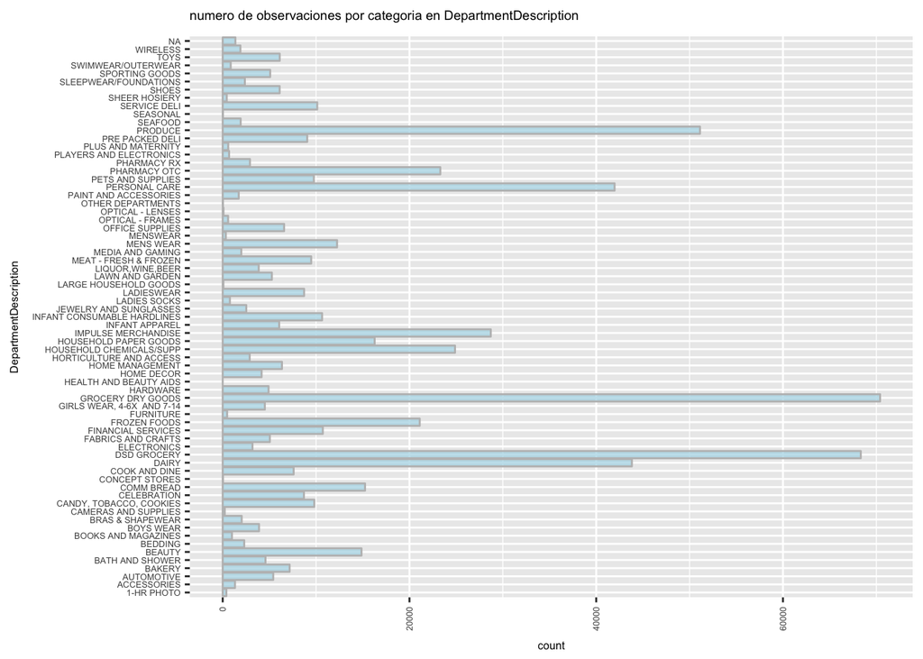

```r
ggplot(train, aes(DepartmentDescription)) +
  geom_bar(colour = 'grey', fill = 'lightblue', alpha = 0.7) +
  theme(axis.text.x = element_text(angle = 90, vjust = 0.5, hjust=1)) +
  theme(text = element_text(size = 6)) +
  labs(title = "numero de observaciones por categoria en DepartmentDescription", x = "DepartmentDescription", y = "count") +
  coord_flip()
```

- Cuál es el resumen y el boxplot del número de observaciones por categoría en `DepartmentDescription` en el dataset `train`?

```r
n_DepartmentDescription <- as.data.frame(table(train$DepartmentDescription))
summary(n_DepartmentDescription$Freq)
```

```
##    Min. 1st Qu.  Median    Mean 3rd Qu.    Max.
##       0     992    4582    9358    9761   70400
```

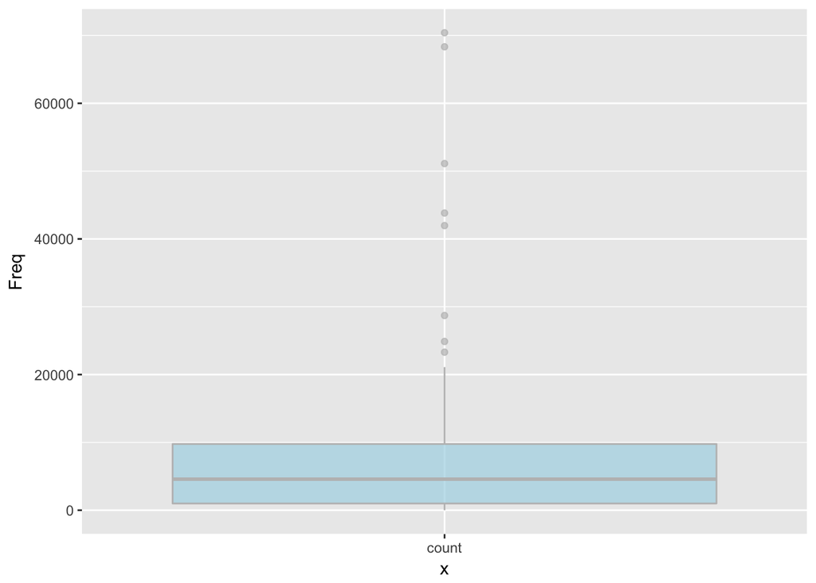

```r
ggplot(n_DepartmentDescription, aes(x = 'count', y = Freq)) +
  geom_boxplot(colour = 'grey', fill = 'lightblue', alpha = 0.7)
```

Cuál es el histograma del número de observaciones por categoría en `DepartmentDescription` en el dataset `train`?

Eliminamos aquellas categorías en `DepartmentDescription` que tienen más de 40000 observaciones.

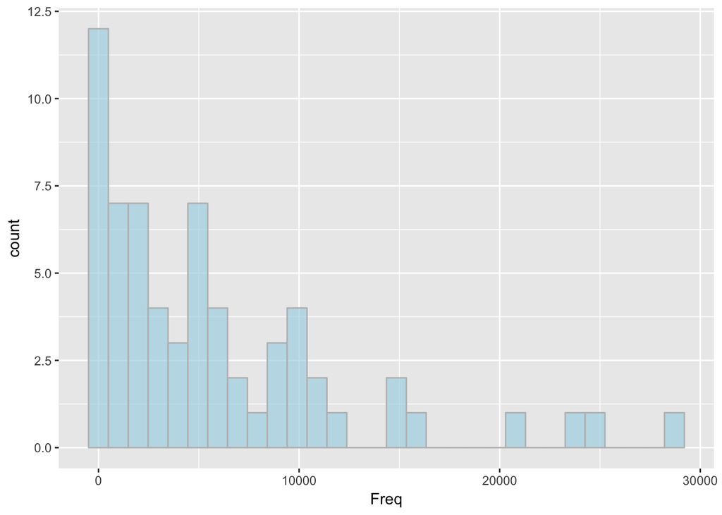

```r
ggplot(n_DepartmentDescription[n_DepartmentDescription$Freq < 40000, ], aes(x = Freq)) +
  geom_histogram(colour = 'grey', fill = 'lightblue', alpha = 0.7)
```

**test**

- Cuántas categorías tiene `DepartmentDescription` en el dataset `test`?

```r
print(paste('numero de categorias:', length(levels(test$DepartmentDescription))))
```

```
## [1] "numero de categorias: 68"
```

- Qué categorías y cuántas observaciones por categoría tiene `DepartmentDescription` en el dataset `test`?

```r
print(summary(test$DepartmentDescription))
```

```
##                  1-HR PHOTO                 ACCESSORIES
##                         394                        1420
##                  AUTOMOTIVE                      BAKERY
##                        5459                        7165
##             BATH AND SHOWER                      BEAUTY
##                        4665                       15223
##                     BEDDING         BOOKS AND MAGAZINES
##                        2203                         909
##                   BOYS WEAR            BRAS & SHAPEWEAR
##                        3886                        2018
##        CAMERAS AND SUPPLIES     CANDY, TOBACCO, COOKIES
##                         247                       10310
##                 CELEBRATION                  COMM BREAD
##                        8635                       15688
##              CONCEPT STORES               COOK AND DINE
##                          49                        7788
##                       DAIRY                 DSD GROCERY
##                       44824                       68860
##                 ELECTRONICS          FABRICS AND CRAFTS
##                        3361                        5170
##          FINANCIAL SERVICES                FROZEN FOODS
##                       10857                       21890
##                   FURNITURE  GIRLS WEAR, 4-6X  AND 7-14
##                         444                        4628
##           GROCERY DRY GOODS                    HARDWARE
##                       72335                        4885
##                  HOME DECOR             HOME MANAGEMENT
##                        4069                        6297
##     HORTICULTURE AND ACCESS    HOUSEHOLD CHEMICALS/SUPP
##                        3040                       24602
##       HOUSEHOLD PAPER GOODS         IMPULSE MERCHANDISE
##                       15642                       28441
##              INFANT APPAREL INFANT CONSUMABLE HARDLINES
##                        6559                       10670
##      JEWELRY AND SUNGLASSES                LADIES SOCKS
##                        2477                         762
##                  LADIESWEAR       LARGE HOUSEHOLD GOODS
##                        9019                         103
##             LAWN AND GARDEN            LIQUOR,WINE,BEER
##                        5521                        3781
```

[output cut: 13 more lines]

```
##                       23293                        2784
##     PLAYERS AND ELECTRONICS          PLUS AND MATERNITY
##                         669                         644
##             PRE PACKED DELI                     PRODUCE
##                        9276                       50928
##                     SEAFOOD                    SEASONAL
##                        2135                          47
##                SERVICE DELI               SHEER HOSIERY
##                       10049                         514
##                       SHOES       SLEEPWEAR/FOUNDATIONS
##                        6214                        2463
##              SPORTING GOODS          SWIMWEAR/OUTERWEAR
##                        5031                         870
##                        TOYS                    WIRELESS
##                        6135                        1810
```

Antes no identificamos NULLs en ninguna columna, pero existe una categoría ‘NULL’ en `DepartmentDescription`.

```r
test$DepartmentDescription[test$DepartmentDescription == 'NULL'] <- NA
```

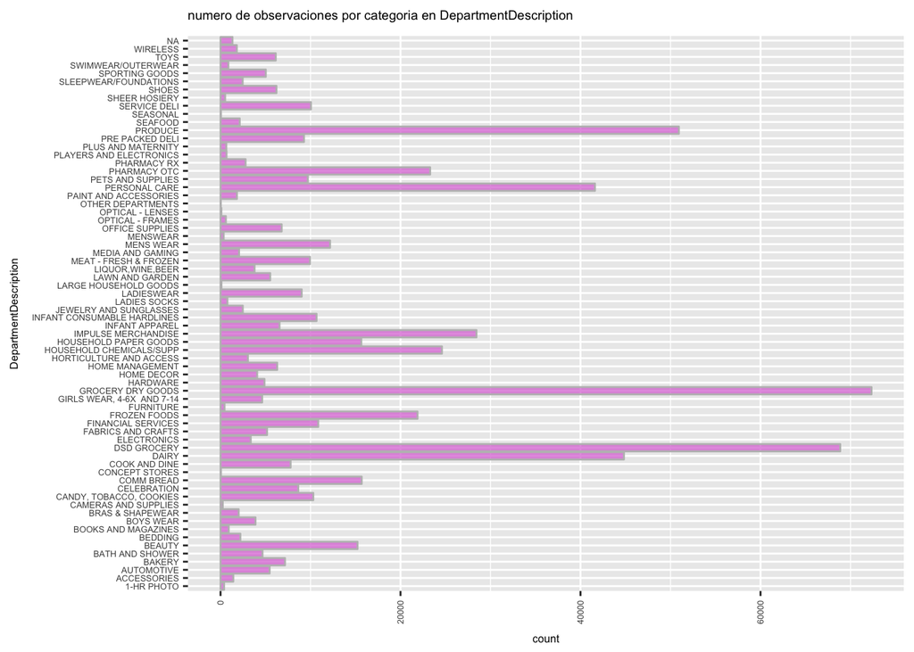

```r
ggplot(test, aes(DepartmentDescription)) +
  geom_bar(colour = 'grey', fill = 'orchid', alpha = 0.7) +
  theme(axis.text.x = element_text(angle = 90, vjust = 0.5, hjust=1)) +
  theme(text = element_text(size = 6)) +
  labs(title = "numero de observaciones por categoria en DepartmentDescription", x = "DepartmentDescription", y = "count") +
  coord_flip()
```

- Cuál es el resumen y el boxplot del número de observaciones por categoría en `DepartmentDescription` en el dataset `test`?

```r
n_DepartmentDescription <- as.data.frame(table(test$DepartmentDescription))
summary(n_DepartmentDescription$Freq)
```

```
##    Min. 1st Qu.  Median    Mean 3rd Qu.    Max.
##       0    1292    4775    9593    9964   72340
```

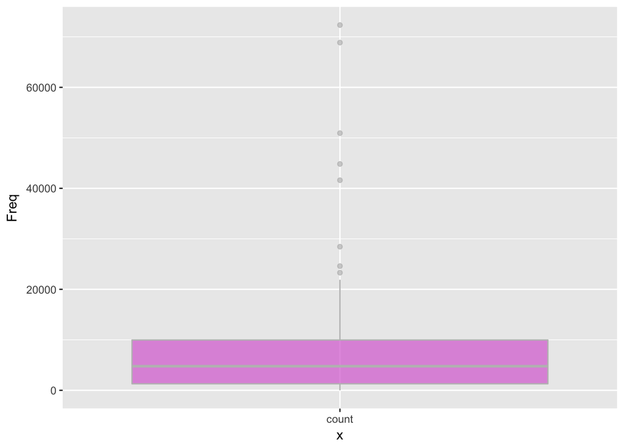

```r
ggplot(n_DepartmentDescription, aes(x = 'count', y = Freq)) +
  geom_boxplot(colour = 'grey', fill = 'orchid', alpha = 0.7)
```

Cuál es el histograma del número de observaciones por categoría en `DepartmentDescription` en el dataset `test`?

Eliminamos aquellas categorías en `DepartmentDescription` que tienen más de 40,000 observaciones

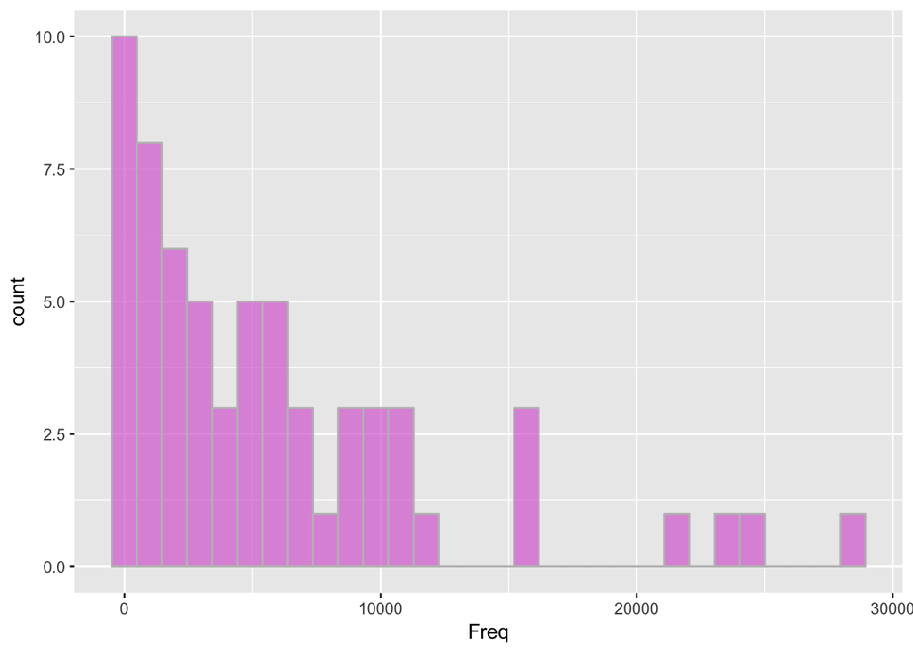

```r
ggplot(n_DepartmentDescription[n_DepartmentDescription$Freq < 40000, ], aes(x = Freq)) +
  geom_histogram(colour = 'grey', fill = 'orchid', alpha = 0.7)
```

#### ScanCount

`ScanCount` es una variable numérica (pero la exploraremos como categórica)

**train**

- Cuántas categorías tiene `ScanCount` en el dataset `train`?

```r
print(paste('numero de categorias:', length(levels(as.factor(train$ScanCount)))))
```

```
## [1] "numero de categorias: 39"
```

- Qué categorías y cuántas observaciones por categoría tiene `ScanCount` en el dataset `train`?

```r
print(summary(as.factor(train$ScanCount)))
```

```
##    -12    -10     -9     -7     -6     -5     -4     -3     -2     -1
##      1      1      2      1     10     16     76    143    814  14394
##      1      2      3      4      5      6      7      8      9     10
## 561489  53002   9445   4536   1380    866    228    246     88    130
##     11     12     13     14     15     16     17     18     19     20
##     45     60     13     15     12      6      3      4      4      7
##     22     23     24     25     30     31     46     51     71
##      2      3      4      3      1      1      1      1      1
```

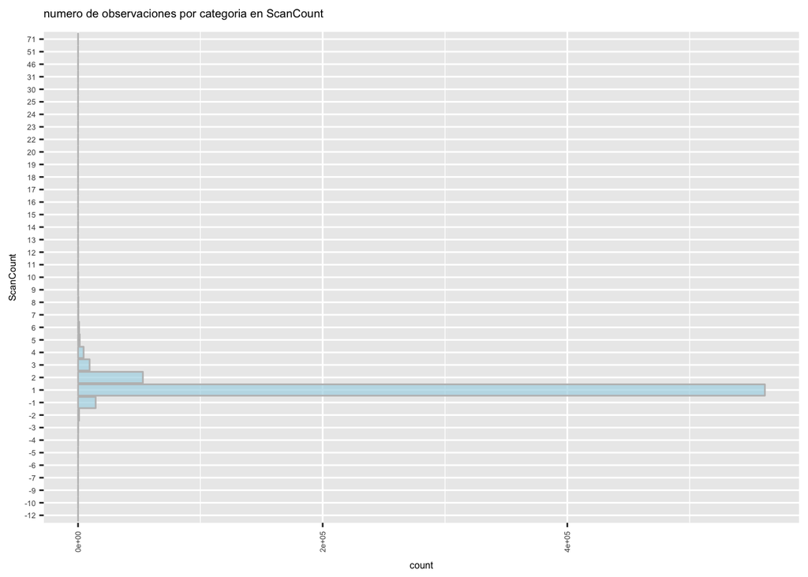

```r
ggplot(train, aes(as.factor(ScanCount))) +
  geom_bar(colour = 'grey', fill = 'lightblue', alpha = 0.7) +
  theme(axis.text.x = element_text(angle = 90, vjust = 0.5, hjust=1)) +
  theme(text = element_text(size = 6)) +
  labs(title = "numero de observaciones por categoria en ScanCount", x = "ScanCount", y = "count") +
  coord_flip()
```

- Cuál es el resumen de `ScanCount` en el dataset `train`?

```r
summary(train$ScanCount)
```

```
##    Min. 1st Qu.  Median    Mean 3rd Qu.    Max.
## -12.000   1.000   1.000   1.109   1.000  71.000
```

**test**

- Cuántas categorías tiene `ScanCount` en el dataset `test`?

```r
print(paste('numero de categorias:', length(levels(as.factor(test$ScanCount)))))
```

```
## [1] "numero de categorias: 49"
```

- Qué categorías y cuántas observaciones por categoría tiene `ScanCount` en el dataset `test`?

```r
print(summary(as.factor(test$ScanCount)))
```

```
##    -21    -14    -11    -10     -9     -8     -7     -6     -5     -4
##      1      1      1      1      1      8      7      7     25     54
##     -3     -2     -1      1      2      3      4      5      6      7
##    146    804  14629 567311  53483   9457   4586   1365    826    249
##      8      9     10     11     12     13     14     15     16     17
##    228    101    127     65     51     23     15     18      8      1
##     18     19     20     22     23     24     26     27     28     29
##      8      6      8      3      1      8      1      1      1      1
##     31     35     36     40     41     42     45     46     55
##      1      1      1      1      1      1      1      1      1
```

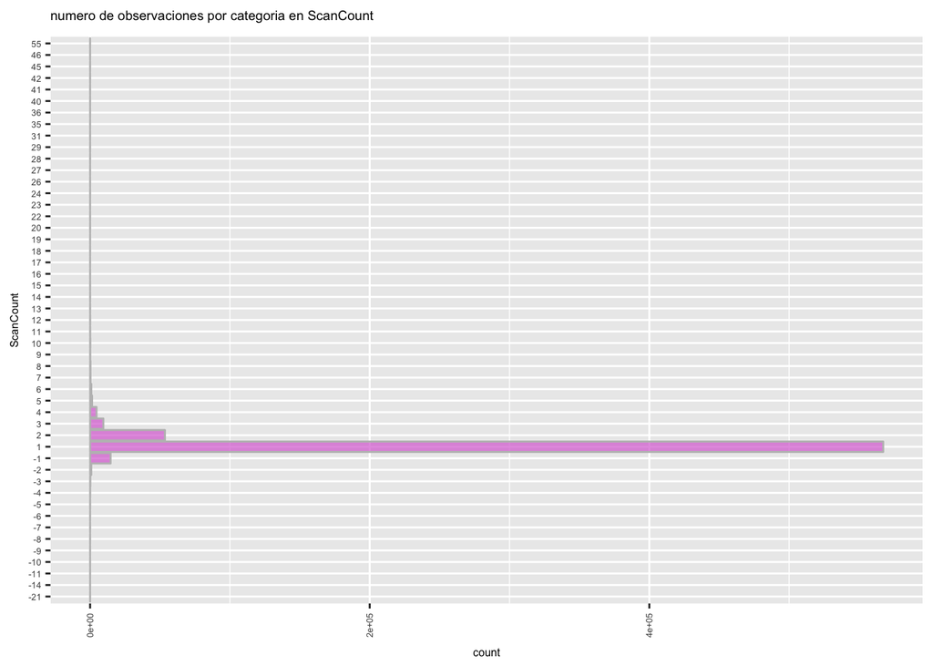

```r
ggplot(test, aes(as.factor(ScanCount))) +
  geom_bar(colour = 'grey', fill = 'orchid', alpha = 0.7) +
  theme(axis.text.x = element_text(angle = 90, vjust = 0.5, hjust=1)) +
  theme(text = element_text(size = 6)) +
  labs(title = "numero de observaciones por categoria en ScanCount", x = "ScanCount", y = "count") +
  coord_flip()
```

- Cuál es el resumen de `ScanCount` en el dataset `test`?

```r
summary(test$ScanCount)
```

```
##    Min. 1st Qu.  Median    Mean 3rd Qu.    Max.
## -21.000   1.000   1.000   1.109   1.000  55.000
```

### Exploración bivariada

En esta sección hacemos una exploración bivariada de las columnas en `test` y `train`.

#### Validaciones

**visits**

```r
visits <- rbind(train[, -1], test) %>%
  distinct(TripType, VisitNumber, Weekday)
```

- Existe un único `TripType` por cada `VisitNumber`?

```r
validacion <- train %>%
  distinct(TripType, VisitNumber, Weekday) %>%
  group_by(VisitNumber) %>%
  summarize(count = n_distinct(TripType)) %>%
  mutate(error = (count != 1))

validacion %>%
  group_by(error) %>%
  summarize(n())
```

```
## # A tibble: 1 x 2
##   error `n()`
##   <lgl> <int>
## 1 FALSE 95674
```

- Existe un único `Weekday` por cada `VisitNumber`?

```r
validacion <- visits %>%
  group_by(VisitNumber) %>%
  summarize(count = n_distinct(Weekday)) %>%
  mutate(error = (count != 1))

validacion %>%
  group_by(error) %>%
  summarize(n())
```

```
## # A tibble: 1 x 2
##   error  `n()`
##   <lgl>  <int>
## 1 FALSE 191348
```

**products**

```r
products <- rbind(train[, -1], test) %>%
  select(Upc, FinelineNumber, DepartmentDescription) %>%
  group_by(Upc, FinelineNumber, DepartmentDescription) %>%
  summarize(num = n())
```

- Existe un único `FinelineNumber` por cada `Upc`?

```r
validacion <- products %>%
  group_by(Upc) %>%
  summarize(count = n_distinct(FinelineNumber)) %>%
  mutate(error = (count != 1))

validacion %>%
  group_by(error) %>%
  summarize(n())
```

```
## # A tibble: 2 x 2
##   error  `n()`
##   <lgl>  <int>
## 1 FALSE 124667
## 2  TRUE     27
```

```r
error <- validacion$Upc[validacion$error]

head(products %>%
  distinct(Upc, FinelineNumber) %>%
  filter(Upc %in% error) %>%
  arrange(as.numeric(Upc)))
```

```
## # A tibble: 6 x 2
## # Groups:   Upc, FinelineNumber [6]
##          Upc FinelineNumber
##       <fctr>         <fctr>
## 1  888852883           1003
## 2  888852883           7701
## 3 1600048286           3825
## 4 1600048286           3953
## 5 1864315950           2035
## 6 1864315950           2061
```

- Existe un único `DepartmentDescription` por cada `Upc`?

```r
validacion <- products %>%
  group_by(Upc) %>%
  summarize(count = n_distinct(DepartmentDescription)) %>%
  mutate(error = (count != 1))

validacion %>%
  group_by(error) %>%
  summarize(n())
```

```
## # A tibble: 2 x 2
##   error  `n()`
##   <lgl>  <int>
## 1 FALSE 124692
## 2  TRUE      2
```

```r
error <- validacion$Upc[validacion$error]

products %>%
  filter(Upc %in% error) %>%
  arrange(as.numeric(Upc))
```

```
## # A tibble: 4 x 4
## # Groups:   Upc, FinelineNumber [3]
##           Upc FinelineNumber DepartmentDescription   num
##        <fctr>         <fctr>                <fctr> <int>
## 1 85651600204           3350           DSD GROCERY     1
## 2 85651600204           7129               PRODUCE    24
## 3        <NA>           <NA>           PHARMACY RX  5426
## 4        <NA>           <NA>                  <NA>  2689
```

- Existe un único `DepartmentDescription` por cada `FinelineNumber`?

```r
validacion <- products %>%
  group_by(FinelineNumber) %>%
  summarize(count = n_distinct(DepartmentDescription)) %>%
  mutate(error = (count != 1))

validacion %>%
  group_by(error) %>%
  summarize(n())
```

```
## # A tibble: 2 x 2
##   error `n()`
##   <lgl> <int>
## 1 FALSE  2688
## 2  TRUE  2666
```

```r
error <- validacion$FinelineNumber[validacion$error]

head(products %>%
  distinct(FinelineNumber, DepartmentDescription) %>%
  filter(FinelineNumber %in% error) %>%
  arrange(as.numeric(FinelineNumber)))
```

```
## # A tibble: 6 x 3
## # Groups:   Upc, FinelineNumber [6]
##           Upc FinelineNumber   DepartmentDescription
##        <fctr>         <fctr>                  <fctr>
## 1  7524320433              0            FROZEN FOODS
## 2 20100100000              0 HORTICULTURE AND ACCESS
## 3 20300100000              0 HORTICULTURE AND ACCESS
## 4 34533432039              0            PHARMACY OTC
## 5 60538804089              0       OTHER DEPARTMENTS
## 6 60538804110              0       OTHER DEPARTMENTS
```

#### Campos vacíos

- Qué entradas en `UPC` y `FinelineNumber` tienen NAs?

```r
products[is.na(products$Upc), ]
```

```
## # A tibble: 2 x 4
## # Groups:   Upc, FinelineNumber [1]
##      Upc FinelineNumber DepartmentDescription   num
##   <fctr>         <fctr>                <fctr> <int>
## 1   <NA>           <NA>           PHARMACY RX  5426
## 2   <NA>           <NA>                  <NA>  2689
```

Las entradas que tienen NAs en `UPC` son las mismas que tienen NAs en `FinelineNumber`.

```r
products[is.na(products$FinelineNumber), ]
```

```
## # A tibble: 2 x 4
## # Groups:   Upc, FinelineNumber [1]
##      Upc FinelineNumber DepartmentDescription   num
##   <fctr>         <fctr>                <fctr> <int>
## 1   <NA>           <NA>           PHARMACY RX  5426
## 2   <NA>           <NA>                  <NA>  2689
```

Las entradas que no tienen `DepartmentDescription` tampoco tienen `Upc` y `FinelineNumber`.

```r
products[is.na(products$DepartmentDescription), ]
```

```
## # A tibble: 1 x 4
## # Groups:   Upc, FinelineNumber [1]
##      Upc FinelineNumber DepartmentDescription   num
##   <fctr>         <fctr>                <fctr> <int>
## 1   <NA>           <NA>                  <NA>  2689
```

#### Visit Number + ScanCount

**items_per_visit**

```r
items_per_visit <- train %>%
  select(VisitNumber, TripType, Weekday, ScanCount) %>%
  group_by(VisitNumber, TripType, Weekday) %>%
  summarize(items_per_visit = sum(ScanCount))
```

- Cuántos artículos se compran por visita?

```r
summary(items_per_visit$items_per_visit)
```

```
##    Min. 1st Qu.  Median    Mean 3rd Qu.    Max.
## -52.000   2.000   4.000   7.499   9.000 311.000
```

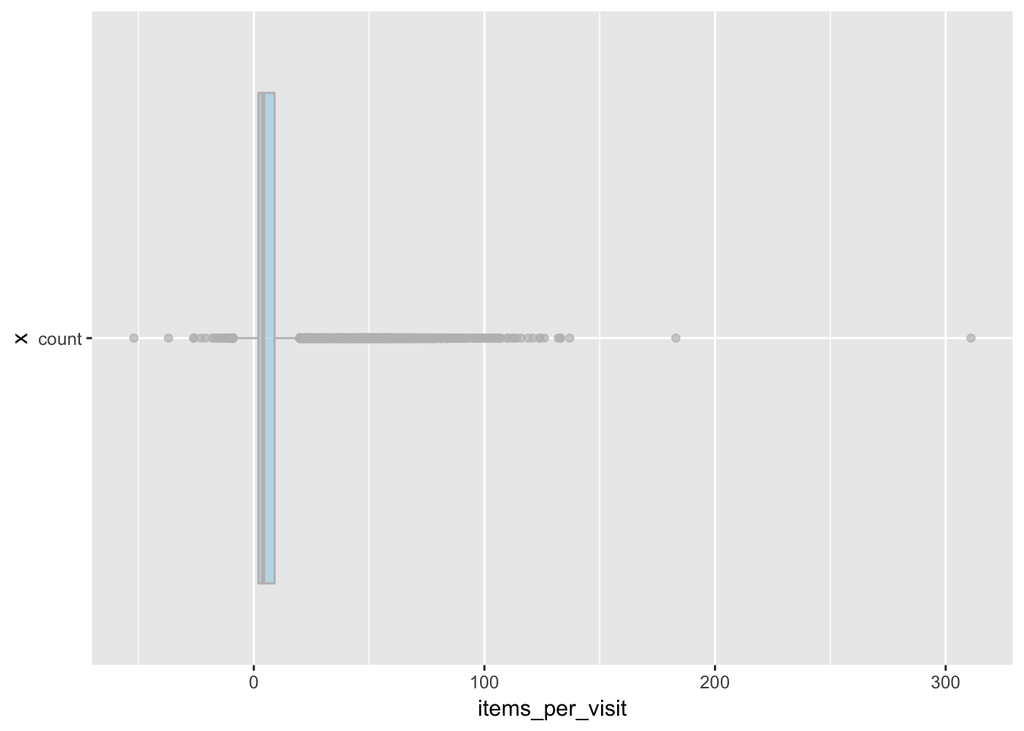

```r
ggplot(items_per_visit, aes(x = 'count', y = items_per_visit)) +
  geom_boxplot(colour = 'grey', fill = 'lightblue', alpha = 0.7) +
  coord_flip()
```

#### VisitNumber + TripType + ScanCode

**rows_per_visit**

```r
rows_per_visit <- train %>%
  select(VisitNumber, TripType, Weekday) %>%
  group_by(VisitNumber, TripType, Weekday) %>%
  summarize(rows_per_visit = n())
```

- Cuántos obervaciones hay por visita por TripType?

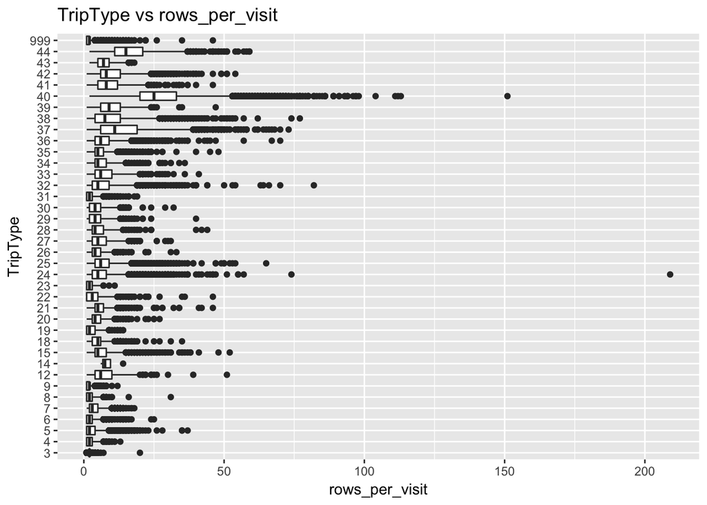

```r
rows_per_visit %>%
  ggplot(aes(x = TripType, y = rows_per_visit)) +
  geom_boxplot() +
  coord_flip() +
  ggtitle("TripType vs rows_per_visit")
```

- Cuántos artículos se compran por visita por TripType?

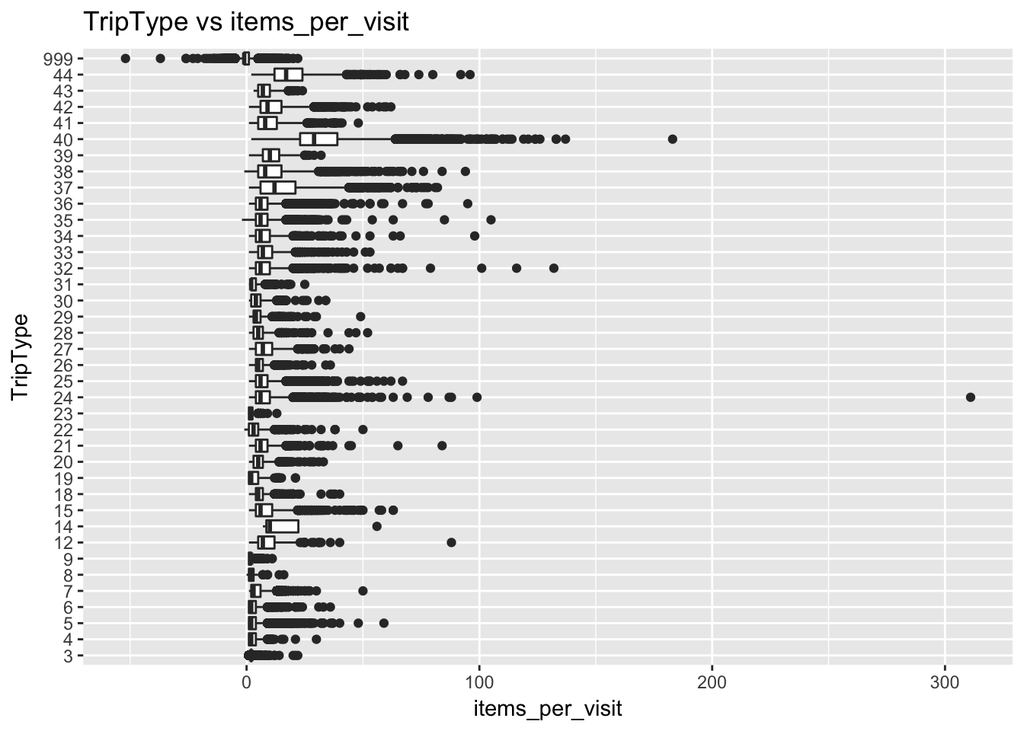

```r
items_per_visit %>%
  ggplot(aes(x = TripType, y = items_per_visit)) +
  geom_boxplot() +
  coord_flip() +
  ggtitle("TripType vs items_per_visit")
```

#### VisitNumber + Weekday + ScanCode

- Cuántos observaciones hay por visita por Weekday?

Filtramos aquellas visitas con más de 125 observaciones.

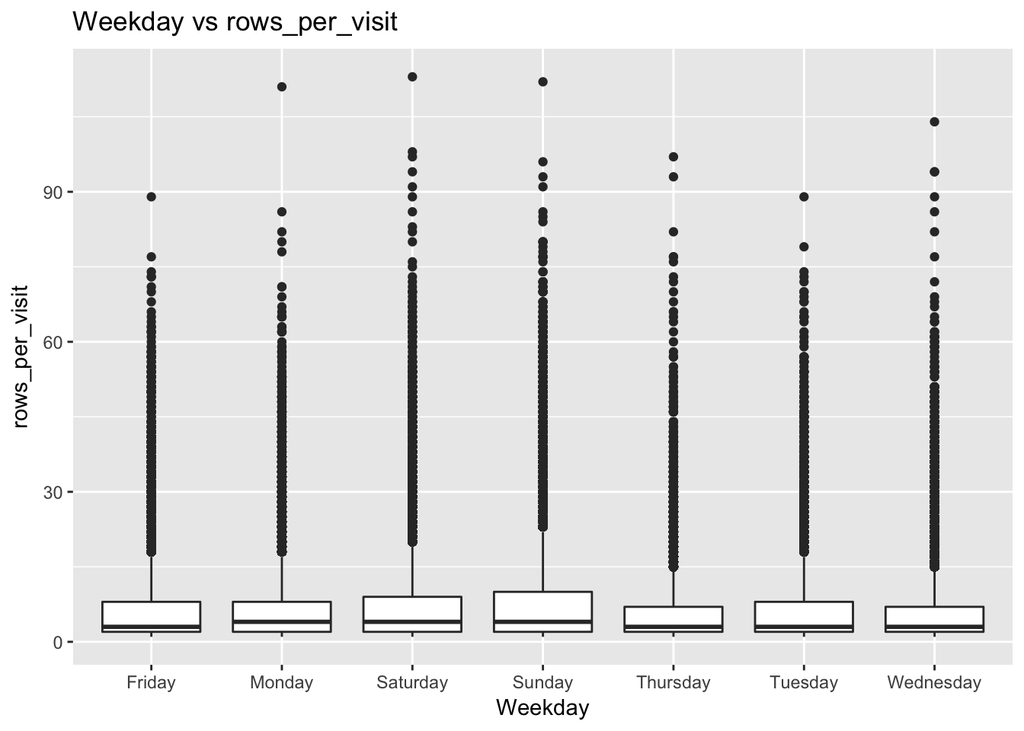

```r
rows_per_visit %>%
  filter(rows_per_visit < 125) %>%
  ggplot(aes(x = Weekday, y = rows_per_visit)) +
  geom_boxplot() +
  ggtitle("Weekday vs rows_per_visit")
```

- Cuántos artículos se compran por visita por Weekday?

Filtramos aquellas visitas con más de 125 artículos comprados.

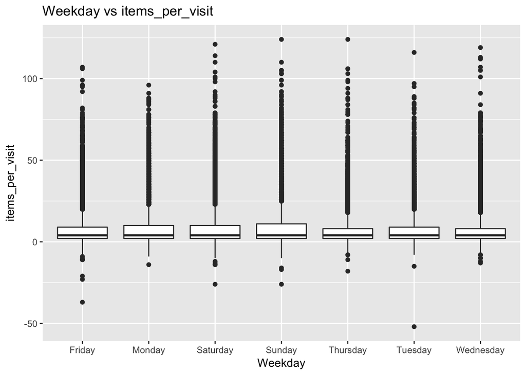

```r
items_per_visit %>%
  filter(items_per_visit < 125) %>%
  ggplot(aes(x = Weekday, y = items_per_visit)) +
  geom_boxplot() +
  ggtitle("Weekday vs items_per_visit")
```

Para resolver el problema tomaremos la distribución por departamento por cada trip type…analysis de correspondencias

por visita encontrar el más cercano